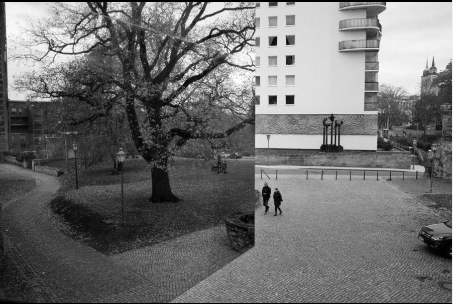

# HBD-Elabudo

How do you see when you want look back in time?  
as the eyes are closed  
and lenses are left to mime

As I was trying  
I remembered that you had given me a mirrorless  
a triangularly shaped kaleidoscopic lens

When I tried to focus it  
it lent me a gaze  
that plunged inside memory lanes  
and I saw that the broken pieces of colored glasses  
were in fact a litany of kertezs, einlasmusiks and soderbergian frames

This kaleidoscopic lens  
measured depth of field not in space but in time  
and so adjusting the aperture  
juxtaposed our pasts and futures in a single composition

And I realised that this composition  
was actually the precise definition of a word  
whose meaning always eluded to me

the mirrorless-  
the lens-  
the word-  
is what I now know as my aesthetic

which you have shaped across time and space  
by identifying the intelligence in geometry  
do play around with the aperture as well  
I am seeing a film when I set it to future

– 28-09-2021